# NEWS ARTICLES CATEGORIZATION WITH MACHINE LEARNING

## Data Extraction and Exploration

- load the data
- Analyse the data
  - number of observations
  - number of features, their types (numeric, categorical etc)
  - target variable determination
  - distribution of observations (number of observations for each category)
  - multi-collinearity (correlation between features)

## Data Processing

- Look for any null values and remove them
- If observations are not evenly distributed across categories, consider various approaches to normalize the distribution
- Convert words in the news articles into numerical features using tfdif

## Model Training and Evaluation

We will use following models:

- Logistic Regression
- Decision Tree
- Random Forest
- Voting Ensemble

  Train and Test datasets are created and model is trained on the train dataset. HyperParameters are tuned and the optimized model is used on test dataset.

  Analysis of the Evaluation Metrics for each model is carried out to interpret the results

  After evaluating the metrics for the above models, we will compare them and recommend the best model to use

# #

## Data Extraction and Exploration

"Pandas" is mainly a package to handle and operate directly on data.

"Scikit-learn" is doing machine learning with emphasis on predictive modeling with often large and sparse data

"Statsmodels" is doing "traditional" statistics and econometrics, with much stronger emphasis on parameter estimation and (statistical) testing.

```python
import pandas as pd
import numpy as np
import statsmodels.api as sm
import re
import seaborn as sns
from sklearn.metrics import classification_report
from sklearn.model_selection import train_test_split
from sklearn.linear_model import LogisticRegression
from sklearn.tree import DecisionTreeClassifier
from sklearn.ensemble import RandomForestClassifier
from sklearn.ensemble import VotingClassifier
from sklearn.model_selection import GridSearchCV

from sklearn.utils import resample

from sklearn.metrics import accuracy_score, confusion_matrix
from sklearn.metrics import roc_curve,auc
from scipy import interp
from itertools import cycle
import matplotlib.pyplot as plt
import seaborn as sns
get_ipython().run_line_magic('matplotlib', 'inline')

from sklearn.metrics import accuracy_score


from textblob import Word
from sklearn.feature_extraction.text import TfidfVectorizer
```

Import the Dataset

Since our file is in CSV format, we will use panda's read_csv method to read our CSV data file Load the data using pandas : Create a DataFrame named my_df, that contains 2 columns

```python
my_df = pd.read_csv("newsdataset.csv", engine='python' )
```

List first 5 entries in dataframe to make sure it was loaded properly and review the various colums in the dataframe

```python
my_df.head()
```

|  | news | type |
| --- | --- | --- |
| 0 | China had role in Yukos split-up\n \n China le... | business |
| 1 | Oil rebounds from weather effect\n \n Oil pric... | business |
| 2 | Indonesia 'declines debt freeze'\n \n Indonesi... | business |
| 3 | $1m payoff for former Shell boss\n \n Shell is... | business |
| 4 | US bank in $515m SEC settlement\n \n Five Bank... | business |

Execute the following command to see the number of rows and columns in our dataset:

```python
print('Shape of the Dataset-->',my_df.shape)
```

```
Shape of the Dataset--> (2225, 2)
```

The output will show "(2225, 2)", which means that our dataset has 2225 records and 2 attributes.

Printing the column indexes of the dataset

```python
print ('Columns Datatype -->', my_df.dtypes)
```

```
Columns Datatype --> news    object
type    object
dtype: object
```

Checking weather there are any null values in that feature and there count

```python
my_df.isnull().sum()
```

```
news    0
type    0
dtype: int64
```

Using visualization check the null values in the dataset

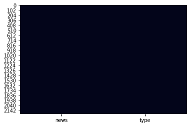

```python
sns.heatmap(my_df.isnull(), cbar=False)
```

There are no null values

```python
my_df.describe()
```

|  | news | type |
| --- | --- | --- |
| count | 2225 | 2225 |
| unique | 2127 | 5 |
| top | Apple unveils low-cost 'Mac mini'\n \n Apple h... | sport |
| freq | 2 | 511 |

Entire information of the data columns,type,memory usage.

```python
my_df.info()
```

```
<class 'pandas.core.frame.DataFrame'>
RangeIndex: 2225 entries, 0 to 2224
Data columns (total 2 columns):
news    2225 non-null object
type    2225 non-null object
dtypes: object(2)
memory usage: 34.8+ KB
```

# Utility Python Functions

### clean_str: Tokenizes and cleans the passed string (remove special characters etc). Returns the cleaned string

```python
def clean_str(string):
    """
    Tokenization/string cleaning for datasets.
    """
    string = re.sub(r"\'s", "", string)
    string = re.sub(r"\'ve", "", string)
    string = re.sub(r"n\'t", "", string)
    string = re.sub(r"\'re", "", string)
    string = re.sub(r"\'d", "", string)
    string = re.sub(r"\'ll", "", string)
    string = re.sub(r",", "", string)
    string = re.sub(r"!", " ! ", string)
    string = re.sub(r"\(", "", string)
    string = re.sub(r"\)", "", string)
    string = re.sub(r"\?", "", string)
    string = re.sub(r"'", "", string)
    string = re.sub(r"[^A-Za-z0-9(),!?\'\`]", " ", string)
    string = re.sub(r"[0-9]\w+|[0-9]","", string)
    string = re.sub(r"\s{2,}", " ", string)
    return string.strip().lower()
```

plot_roc: Function to plot ROC Curve given the model, x data and y data as inputs

```python
def plot_roc(roc_model, testx, testy):
    """
      Plots ROC Curve for the specified model
    """
    n_classes=5
    pred1=roc_model.predict(testx)
    ### MACRO
    fpr = dict()
    tpr = dict()
    roc_auc = dict()

    for i in range(n_classes):
        fpr[i], tpr[i], _ = roc_curve(np.array(pd.get_dummies(testy))[:, i], np.array(pd.get_dummies(pred1))[:, i])
        roc_auc[i] = auc(fpr[i], tpr[i])
    all_fpr = np.unique(np.concatenate([fpr[i] for i in range(n_classes)]))
    mean_tpr = np.zeros_like(all_fpr)
    for i in range(n_classes):
        mean_tpr += interp(all_fpr, fpr[i], tpr[i])
    mean_tpr /= n_classes
    fpr["macro"] = all_fpr
    tpr["macro"] = mean_tpr
    roc_auc["macro"] = auc(fpr["macro"], tpr["macro"])
    lw=2
    plt.figure(figsize=(8,5))
    plt.plot(fpr["macro"], tpr["macro"],
         label='macro-average ROC curve (area = {0:0.2f})'
               ''.format(roc_auc["macro"]),
         color='green', linestyle=':', linewidth=4)
    colors = cycle(['aqua', 'darkorange', 'cornflowerblue'])
    for i, color in zip(range(n_classes), colors):
        plt.plot(fpr[i], tpr[i], color=color, lw=lw,
             label='ROC curve of class {0} (area = {1:0.2f})'
             ''.format(i, roc_auc[i]))
    plt.plot([0, 1], [0, 1], 'k--',color='red', lw=lw)
    plt.xlim([0.0, 1.0])
    plt.ylim([0.0, 1.05])
    plt.annotate('Random Guess',(.5,.48),color='red')
    plt.xlabel('False Positive Rate')
    plt.ylabel('True Positive Rate')
    plt.title('Receiver Operating Characteristic for ' + roc_model.__class__.__name__ )
    plt.legend(loc="lower right")
    plt.show()
```

Converting 2 columns into list from dataframe

```python
x = my_df['news'].tolist()
y = my_df['type'].tolist()
```

Import NLTK(Natural Language Tool Kit ) to download worknet library

```python
import nltk
nltk.download('wordnet')
```

```
True
```

Using lemmatize function we are cleaning the data by removing grammatical variations such as -ing, -ed suffixes etc.

```python
for index,value in enumerate(x):
    x[index] = ' '.join([Word(word).lemmatize() for word in clean_str(value).split()])
```

The Column X(news) to vectorize the data and transform the data .

# Convert words in the news articles into numerical features using tfdif

tfidf (term frequency–inverse document frequency) vectorization capabilities in sklearn are used to determine the importance of the word across the document sets

"min_df" is the minimum numbers of documents a word must be present in to be kept, and we are setting it to 5. This is to avoid rare words, which drastically increase the size of our features and might cause overfitting.

norm is set to l2, to ensure all our feature vectors have a euclidian norm of 1. This is helpful for visualizing these vectors, and can also improve (or deteriorate) the performance of some models.

stop_words is set to "english" to remove all common pronouns ("a", "the", ...) and further reduce the number of noisy features.

```python
vect = TfidfVectorizer(stop_words='english',min_df=5)
X = vect.fit_transform(x)
Y = np.array(y)

print ("number of features extracted:",X.shape[1])
```

```
number of features extracted: 7823
```

```python
X.shape
```

```
(2225, 7823)
```

```python
Y.shape
```

```
(2225,)
```

The column Target type with 5 classes to factorize and save into Category Machine Learning Algorithms work better with numeric classes/categorization

```python
my_df['Category'] = my_df['type'].factorize()[0]
```

Printing the top 20 rows of the Category after converting into numeric

```python
my_df['Category'][0:20]
```

```
0     0
1     0
2     0
3     0
4     0
5     0
6     0
7     0
8     0
9     0
10    0
11    0
12    0
13    0
14    0
15    0
16    0
17    0
18    0
19    0
Name: Category, dtype: int64
```

Create a new pandas dataframe "category_id_df", which only has unique Categories, also sorting this list in order of category_id values

```python
category_id_df = my_df[['type', 'Category']].drop_duplicates().sort_values('Category')
```

```python
category_id_df
```

|  | type | Category |
| --- | --- | --- |
| 0 | business | 0 |
| 510 | entertainment | 1 |
| 896 | politics | 2 |
| 1313 | sport | 3 |
| 1824 | tech | 4 |

```python
# Create a dictionary ( python datastructure - like a lookup table) that
# can easily convert category names into category_ids and vice-versa
category_to_id = dict(category_id_df.values)
id_to_category = dict(category_id_df[['Category', 'type']].values)
```

```python
id_to_category
```

```
{0: 'business', 1: 'entertainment', 2: 'politics', 3: 'sport', 4: 'tech'}
```

Pick 5 random samples from the dataframe

```python
my_df.sample(5, random_state=0)
```

|  | news | type | Category |
| --- | --- | --- | --- |
| 384 | Jobs go at Oracle after takeover\n \n Oracle h... | business | 0 |
| 1983 | Virgin Radio offers 3G broadcast\n \n UK broad... | tech | 4 |
| 985 | Kennedy looks to election gains\n \n They may ... | politics | 2 |
| 1386 | Pountney handed ban and fine\n \n Northampton ... | sport | 3 |
| 1294 | UK set to cut back on embassies\n \n Nine over... | politics | 2 |

Group the dataframe by categories and count items ( number of news articles) in each category

```python
my_df.groupby('type').Category.count()
```

```
type
business         510
entertainment    386
politics         417
sport            511
tech             401
Name: Category, dtype: int64
```

Plot the distribution of news articles by category

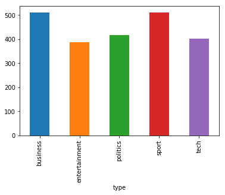

```python
my_df.groupby('type').Category.count().plot.bar(ylim=0)
```

# Observations from Data Exploration and Processing

## APPLY MACHINE LEARNING MODELS

## LOGISTIC REGRESSION

Create Train and Test Datasets 75:25 split is done for train:test

```
     #y: Single column dataframe holding our solution vector for logistic regression
     #x: A dataframe that runs parallel to y, with all the features for our logistic regression
```

# Fit Logistic Regression on training data

```python
lr_model = LogisticRegression(random_state=0)

X_train, X_test, y_train, y_test, indices_train, indices_test = train_test_split(X, Y, my_df.index, test_size=0.25, random_state=666)
```

```python
lr_model.fit(X_train, y_train)
```

```
LogisticRegression(C=1.0, class_weight=None, dual=False, fit_intercept=True,
          intercept_scaling=1, max_iter=100, multi_class='warn',
          n_jobs=None, penalty='l2', random_state=0, solver='warn',
          tol=0.0001, verbose=0, warm_start=False)
```

Note that we didn't have to encode the response variable while using scikit-learn. We can also check the classes as:

```python
lr_model.classes_
```

```
array(['business', 'entertainment', 'politics', 'sport', 'tech'],
      dtype='<U13')
```

```python
y_pred_proba = lr_model.predict_proba(X_test)
predictions  = lr_model.predict(X_test)
```

```python
y_pred_proba
```

```
array([[0.80122718, 0.05926389, 0.03387756, 0.04884427, 0.0567871 ],
       [0.15268889, 0.12216841, 0.08802606, 0.54558471, 0.09153194],
       [0.06058752, 0.77232811, 0.07298732, 0.03249507, 0.06160198],
       ...,
       [0.21372946, 0.12003935, 0.19871552, 0.10294348, 0.36457219],
       [0.15130153, 0.44045834, 0.11803201, 0.18151953, 0.10868858],
       [0.08754306, 0.04114678, 0.04931017, 0.04855885, 0.77344114]])
```

# Calculating the score of train dataset

```python
lr_model.score(X_train, y_train)
```

```
0.9940047961630696
```

# Calculating the score of test dataset

```python
# Calculating the score of test dataset of model
lr_model.score(X_test, y_test)
```

```
0.9820466786355476
```

Error in prediction

```python
1-lr_model.score(X_test, y_test)
```

```
0.01795332136445238
```

# Calculate Accuracy

```python
accuracy_score(y_test, predictions)
```

```
0.9820466786355476
```

Now let's compare some of our predicted values with the actual values and see how accurate we were

```python
df_logistic=pd.DataFrame({'Actual':y_test, 'Predicted':predictions})
df_logistic.head()
```

|  | Actual | Predicted |
| --- | --- | --- |
| 0 | business | business |
| 1 | sport | sport |
| 2 | entertainment | entertainment |
| 3 | tech | tech |
| 4 | sport | sport |

Remember that in your case the records compared may be different, depending upon the training and testing split. Since the train_test_split method randomly splits the data we likely won't have the same training and test sets.

# Calculate number of correctly classified observations

```python
accuracy_score(y_test, predictions, normalize=False)
```

```
547
```

# Calculate number of incorrectly classified observations.

```python
len(y_test) - accuracy_score(y_test, predictions, normalize=False)
```

```
10
```

```python
print('Accuracy of logistic regression classifier on test set: {:.2f}'.format(lr_model.score(X_test, y_test)))
```

```
Accuracy of logistic regression classifier on test set: 0.98
```

Using classification_report we can check the total precision,recall,f1-score,support of the individual classes of the target data

```python
print(classification_report(y_test, predictions ))
```

```
               precision    recall  f1-score   support

     business       0.96      0.99      0.97       135
entertainment       1.00      0.98      0.99        85
     politics       0.99      0.96      0.98       104
        sport       0.98      1.00      0.99       131
         tech       0.99      0.98      0.99       102

    micro avg       0.98      0.98      0.98       557
    macro avg       0.98      0.98      0.98       557
 weighted avg       0.98      0.98      0.98       557
```

As can be seen in classification report, Business and Politics have slightly lower F1-score. This can be examined in more detail with confusion matrix

# Confusion matrix

```python
lr_confusion_mat = confusion_matrix(y_test, predictions)
```

```python
confusion_df = pd.DataFrame(lr_confusion_mat, index=['Business','Entertainment',"Politics",'Sports','Tech'], columns=['Business','Entertainment',"Politics",'Sports','Tech'])
```

```python
confusion_df
```

|  | Business | Entertainment | Politics | Sports | Tech |
| --- | --- | --- | --- | --- | --- |
| Business | 133 | 0 | 0 | 1 | 1 |
| Entertainment | 1 | 83 | 1 | 0 | 0 |
| Politics | 3 | 0 | 100 | 1 | 0 |
| Sports | 0 | 0 | 0 | 131 | 0 |
| Tech | 1 | 0 | 0 | 1 | 100 |

visualisation of confustion matrix

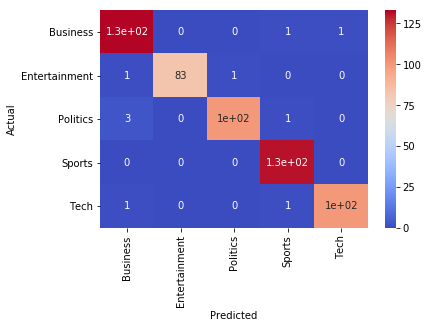

```python
_=sns.heatmap(confusion_df, cmap='coolwarm', annot=True)
plt.ylabel('Actual')
plt.xlabel('Predicted')
```

As can be seen in confusion matrix, 3 articles of 'Politics' for classified as 'Business' in the prediction

Calculate Area under the ROC curve and also plot the ROC curve

```python
probs = lr_model.predict_proba(X_test)[::,1]
```

**Area and Roc Curve with Multiple classes of target valriable(5)

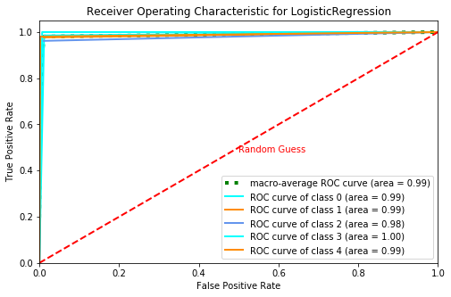

```python
plot_roc(lr_model, X_test, y_test)
```

## Analysis of Logistic Regression Evaluation Metrics

1. Accuracy of both train and test models are very high (> 95%). There is no overfitting as accuracy scores are equally high on both train and test data
2. ROC curve is close to ideal as can be seen compared with random guess.
3. **Precision and recall scores**

   Recall or Sensitivity or TPR (True Positive Rate) measures the items correctly identified as positive out of total true positives

   Precision Measures the Number of items correctly identified as positive out of total items identified as positive

   F1 score combines both the above

   In this dataset, F1 score is of significance as the business needs do not have any weightage on recall or precision

   Weighted Avg of F1 score on Test Data is 98%

# Decision Tree for Classification

# Preparing the Data

As with the classification task, in this section we will divide our data into attributes and labels and consequently into training and test sets.

Execute the following commands to divide data into labels and attributes:

# Splitting the data into train (75%) and test(25%) of dependent and independent variables with random_state(seed) as 666

# Provided:

```
 y: Single column dataframe holding our solution vector for classification
 x: A dataframe that runs parallel to y, with all the features for our classification
```

# Training and Making Predictions

To train the tree, we'll instantiate the DecisionTreeClassifier type and call the fit method:

```python
tree = DecisionTreeClassifier()
```

```python
tree.fit(X_train, y_train)
```

```
DecisionTreeClassifier(class_weight=None, criterion='gini', max_depth=None,
            max_features=None, max_leaf_nodes=None,
            min_impurity_decrease=0.0, min_impurity_split=None,
            min_samples_leaf=1, min_samples_split=2,
            min_weight_fraction_leaf=0.0, presort=False, random_state=None,
            splitter='best')
```

Note that we didn't have to encode the response variable while using scikit-learn. We can also check the classes as:

```python
tree.classes_
```

```
array(['business', 'entertainment', 'politics', 'sport', 'tech'],
      dtype='<U13')
```

**Predictions of train data with X_train

```python
DT_predictions = tree.predict(X_train)
```

```python
DT_predictions[:5]
```

```
array(['entertainment', 'sport', 'sport', 'tech', 'tech'], dtype='<U13')
```

```python
y_train[:5]
```

```
array(['entertainment', 'sport', 'sport', 'tech', 'tech'], dtype='<U13')
```

As can be seen above, model was able to accurately predict for all 5 Y values

# Calculating the score of train dataset

```python
tree.score(X_train,y_train)
```

```
1.0
```

```python
accuracy_score(y_train, DT_predictions)
```

```
1.0
```

# Apply the model to test dataset

Predictions of test data with X_test

```python
DT_predictions = tree.predict(X_test)
```

```python
DT_predictions[:5]
```

```
array(['business', 'sport', 'politics', 'tech', 'sport'], dtype='<U13')
```

```python
y_test[:5]
```

```
array(['business', 'sport', 'entertainment', 'tech', 'sport'],
      dtype='<U13')
```

```python
# Calculating the score of test dataset of model
tree.score(X_test, y_test)
```

```
0.8761220825852782
```

Error in prediction

```python
1-tree.score(X_test, y_test)
```

```
0.12387791741472176
```

# Calculate Accuracy

```python
accuracy_score(y_test, DT_predictions)
```

```
0.8761220825852782
```

Now let's compare some of our predicted values with the actual values and see how accurate we were

```python
df_Decision=pd.DataFrame({'Actual':y_test, 'Predicted':DT_predictions})
df_Decision.head()
```

|  | Actual | Predicted |
| --- | --- | --- |
| 0 | business | business |
| 1 | sport | sport |
| 2 | entertainment | politics |
| 3 | tech | tech |
| 4 | sport | sport |

Remember that in your case the records compared may be different, depending upon the training and testing split. Since the train_test_split method randomly splits the data we likely won't have the same training and test sets.

# Calculate number of correctly classified observations

```python
accuracy_score(y_test, DT_predictions, normalize=False)
```

```
488
```

# Calculate number of incorrectly classified observations.

```python
len(y_test) - accuracy_score(y_test, DT_predictions, normalize=False)
```

```
69
```

```python
print('Accuracy of Decision Tree Classifier on test set: {:.2f}'.format(tree.score(X_test, y_test)))
```

```
Accuracy of Decision Tree Classifier on test set: 0.88
```

Using classification_report we can check the total precision,recall,f1-score,support of the individual classes of the target data

```python
print(classification_report(y_test, DT_predictions ))
```

```
               precision    recall  f1-score   support

     business       0.87      0.86      0.87       135
entertainment       0.90      0.86      0.88        85
     politics       0.81      0.84      0.82       104
        sport       0.92      0.92      0.92       131
         tech       0.88      0.90      0.89       102

    micro avg       0.88      0.88      0.88       557
    macro avg       0.88      0.87      0.87       557
 weighted avg       0.88      0.88      0.88       557
```

As can be seen, across most categories, the test predictions are not that accurate (averaging around 87%)  
A possible reason could be overfitting happening in train data Decision Tree modeling is prone to overfitting

# Confusion matrix

```python
confusion_mat_DT = confusion_matrix(y_test, DT_predictions)
confusion_df_DT = pd.DataFrame(confusion_mat_DT, index=['Business','Entertainment',"Politics",'Sports','Tech'],                            columns=['Business','Entertainment',"Politics",'Sports','Tech'])
```

```python
confusion_df_DT
```

|  | Business | Entertainment | Politics | Sports | Tech |
| --- | --- | --- | --- | --- | --- |
| Business | 116 | 3 | 9 | 2 | 5 |
| Entertainment | 2 | 73 | 4 | 3 | 3 |
| Politics | 7 | 1 | 87 | 6 | 3 |
| Sports | 0 | 4 | 5 | 120 | 2 |
| Tech | 8 | 0 | 2 | 0 | 92 |

# visualisation of confustion matrix

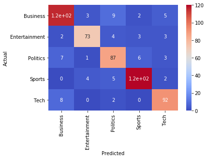

```python
_=sns.heatmap(confusion_df_DT, cmap='coolwarm', annot=True)
plt.ylabel('Actual')
plt.xlabel('Predicted')
```

As can be seen in confusion matrix above, more number of articles are mis-classified as compared to Logistic Regression Also, while Business and Politics confusion is higher than others, there are considerable mis-classifications in Entertainment too.

# Calculate Area under the ROC curve and also plot the ROC curve

```python
probs_DT = tree.predict_proba(X_test)[::,1]
```

**Area and Roc Curve with Multiple classes of target variable(5)

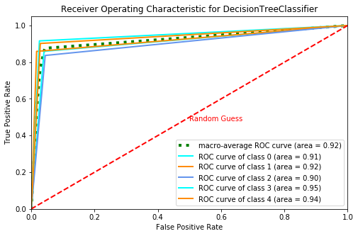

```python
plot_roc(tree, X_test, y_test)
```

# Classification using Decision Tree with GridSearch and Cross-Validation

GridSearch (HyperParemeters) will be leveraged to see if we can improve the accuracy

Import Decision Tree Classification, and GridSearchCV and fit the model to the training data.

Let's use GridSearchCV to try max_depth values 11,21,22,33,34,35,36,37,38,39,40,41,42,43,44,55 and 7000 value for max_features hyperparameters. Specify 10 number of folds.

```python
param_grid = [{"max_depth":[11,21,22,33,34,35,36,37,38,39,40,41,42,43,44,55], "max_features":[7000]}]
```

Now using the decisionTreeRegression with randon value 123

```python
gs = GridSearchCV(estimator=DecisionTreeClassifier(random_state=123),
 param_grid = param_grid,
 cv=10)
```

Fit the training data

```python
gs.fit(X_train, y_train)
```

```
GridSearchCV(cv=10, error_score='raise-deprecating',
       estimator=DecisionTreeClassifier(class_weight=None, criterion='gini', max_depth=None,
            max_features=None, max_leaf_nodes=None,
            min_impurity_decrease=0.0, min_impurity_split=None,
            min_samples_leaf=1, min_samples_split=2,
            min_weight_fraction_leaf=0.0, presort=False, random_state=123,
            splitter='best'),
       fit_params=None, iid='warn', n_jobs=None,
       param_grid=[{'max_depth': [11, 21, 22, 33, 34, 35, 36, 37, 38, 39, 40, 41, 42, 43, 44, 55], 'max_features': [7000]}],
       pre_dispatch='2*n_jobs', refit=True, return_train_score='warn',
       scoring=None, verbose=0)
```

It is observed that gridsearch fitting takes time - it is computationally intensive

Print out all the hyperparameters combinations that the GridSearchCV has tried.

```python
gs.cv_results_['params']
```

```
[{'max_depth': 11, 'max_features': 7000},
 {'max_depth': 21, 'max_features': 7000},
 {'max_depth': 22, 'max_features': 7000},
 {'max_depth': 33, 'max_features': 7000},
 {'max_depth': 34, 'max_features': 7000},
 {'max_depth': 35, 'max_features': 7000},
 {'max_depth': 36, 'max_features': 7000},
 {'max_depth': 37, 'max_features': 7000},
 {'max_depth': 38, 'max_features': 7000},
 {'max_depth': 39, 'max_features': 7000},
 {'max_depth': 40, 'max_features': 7000},
 {'max_depth': 41, 'max_features': 7000},
 {'max_depth': 42, 'max_features': 7000},
 {'max_depth': 43, 'max_features': 7000},
 {'max_depth': 44, 'max_features': 7000},
 {'max_depth': 55, 'max_features': 7000}]
```

Print best hyperparameters combination

```python
gs.best_params_
```

```
{'max_depth': 36, 'max_features': 7000}
```

Print best hyperparameters combination

```python
gs.cv_results_['rank_test_score']
```

```
array([16, 15, 14, 12, 13, 11,  1,  1,  1,  1,  1,  1,  1,  1,  1,  1])
```

Print the complete DecisionTree estimator.

```python
gs.best_estimator_
```

```
DecisionTreeClassifier(class_weight=None, criterion='gini', max_depth=36,
            max_features=7000, max_leaf_nodes=None,
            min_impurity_decrease=0.0, min_impurity_split=None,
            min_samples_leaf=1, min_samples_split=2,
            min_weight_fraction_leaf=0.0, presort=False, random_state=123,
            splitter='best')
```

Make predictions for the test set.

```python
DT_predictions_1 = gs.predict(X_test)
```

Now let's compare some of our predicted values with the actual values and see how accurate

```python
df_Hyper_Dt=pd.DataFrame({'Actual':y_test, 'Predicted':DT_predictions_1})
df_Hyper_Dt.head()
```

|  | Actual | Predicted |
| --- | --- | --- |
| 0 | business | business |
| 1 | sport | sport |
| 2 | entertainment | politics |
| 3 | tech | tech |
| 4 | sport | sport |

# Calculating the score of train dataset

```python
gs.score(X_train,y_train)
```

```
1.0
```

# Fit the test dataset and Calculate the score of test dataset

```python
gs.score(X_test,y_test)
```

```
0.874326750448833
```

Error in prediction

```python
1-gs.score(X_test, y_test)
```

```
0.125673249551167
```

# Calculate Accuracy

```python
accuracy_score(y_test, DT_predictions_1)
```

```
0.874326750448833
```

**Using classification_report we can check the total precision,recall,f1-score,support of the individual classes of the target data

```python
from sklearn.metrics import classification_report
print(classification_report(y_test, DT_predictions_1))
```

```
               precision    recall  f1-score   support

     business       0.85      0.83      0.84       135
entertainment       0.92      0.84      0.88        85
     politics       0.83      0.87      0.85       104
        sport       0.94      0.92      0.93       131
         tech       0.84      0.91      0.87       102

    micro avg       0.87      0.87      0.87       557
    macro avg       0.88      0.87      0.87       557
 weighted avg       0.88      0.87      0.87       557
```

# Confusion matrix

```python
confusion_mat_Dt_HP = confusion_matrix(y_test, DT_predictions_1)
confusion_df_1 = pd.DataFrame(confusion_mat_Dt_HP, index=['Business','Entertainment',"Politics",'Sports','Tech'],                            columns=['Business','Entertainment',"Politics",'Sports','Tech'])
```

```python
confusion_df_1
```

|  | Business | Entertainment | Politics | Sports | Tech |
| --- | --- | --- | --- | --- | --- |
| Business | 112 | 2 | 11 | 2 | 8 |
| Entertainment | 4 | 71 | 4 | 3 | 3 |
| Politics | 7 | 1 | 90 | 2 | 4 |
| Sports | 2 | 3 | 2 | 121 | 3 |
| Tech | 7 | 0 | 1 | 1 | 93 |

visualisation of confustion matrix

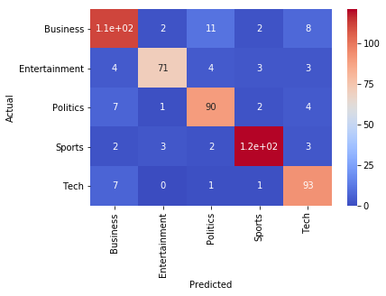

```python
_=sns.heatmap(confusion_df_1, cmap='coolwarm', annot=True)
plt.ylabel('Actual')
plt.xlabel('Predicted')
```

As can be seen in confusion matrix, 11 actual Business articles got classified as Politics in the prediction. Also, 8 business articles were predicted to be Tech. And 7 Tech articles got classified as Busines. In other words, more training is needed especially on business article word classifiers

# Calculate number of correctly classified observations

```python
accuracy_score(y_test, DT_predictions_1, normalize=False)
```

```
487
```

# Calculate number of incorrectly classified observations.

```python
len(y_test) - accuracy_score(y_test, DT_predictions_1, normalize=False)
```

```
70
```

# Calculate Area under the ROC curve and also plot the ROC curve

```python
probs_DT_H = gs.predict_proba(X_test)[::,1]
```

**Area and Roc Curve with Multiple classes of target valriable(5)

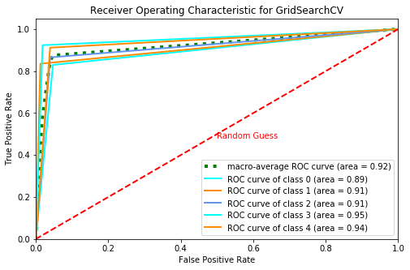

```python
plot_roc(gs, X_test, y_test)
```

## Let us use bootstrap resampling to see if it helps improve DT Accuracy for our data

# Resample

Create a list containing indices of our dataset

```python
nrows = my_df.shape[0]
all_indices = list(range(nrows))
```

Take out indices for training samples from this list with replacement. Let the number of samples be 70% of the original number of observations.

```python
train_indices = resample(all_indices, replace=True, n_samples=int(0.7*nrows), random_state=123)
```

Length of train indices

```python
len(train_indices)
```

```
1557
```

```python
test_indices = [index for index in list(range(nrows)) if index not in train_indices]
```

Length of test indices

```python
len(test_indices)
```

```
1099
```

Based on these indices, get train and test dataframe.

```python
train_df = my_df.take(train_indices)
```

Converting 2 columns into list from dataframe

```python
test_df = my_df.take(test_indices)

resample_x = train_df['news'].tolist()
resample_y = train_df['type'].tolist()
```

Using lemmatize function we are cleaning the data by Spliting .

```python
for index,value in enumerate(resample_x):
   # print ("processing data:",index)
    resample_x[index] = ' '.join([Word(word).lemmatize() for word in clean_str(value).split()])
```

# Convert words in the news articles into numerical features using tfdif

```python
vect = TfidfVectorizer(stop_words='english',min_df=2)
resample_X = vect.fit_transform(resample_x)
resample_Y = np.array(resample_y)

print ("number of features extracted:",resample_X.shape[1])
```

```
number of features extracted: 13007
```

# Preparing the Data

As with the classification task, in this section we will divide our data into attributes and labels and consequently into training and test sets.

```python
x_train, x_test, Y_train, Y_test = train_test_split(resample_X, resample_Y, test_size=0.25, random_state=123)

print ("train size:", x_train.shape)
print ("test size:", x_test.shape)
```

```
train size: (1167, 13007)
test size: (390, 13007)
```

Train the model on training data.

```python
model_resample = DecisionTreeClassifier()

model_resample.fit(x_train, Y_train)
```

```
DecisionTreeClassifier(class_weight=None, criterion='gini', max_depth=None,
            max_features=None, max_leaf_nodes=None,
            min_impurity_decrease=0.0, min_impurity_split=None,
            min_samples_leaf=1, min_samples_split=2,
            min_weight_fraction_leaf=0.0, presort=False, random_state=None,
            splitter='best')
```

Note that we didn't have to encode the response variable whhile using scikit-learn. We can also check the classes as:

```python
model_resample.classes_
```

```
array(['business', 'entertainment', 'politics', 'sport', 'tech'],
      dtype='<U13')
```

**Predictions of train data with X_test

```python
resample_predictions = model_resample.predict(x_test)
```

```python
resample_predictions[:5]
```

```
array(['tech', 'business', 'sport', 'business', 'sport'], dtype='<U13')
```

# Calculating the score of train dataset

```python
model_resample.score(x_train,Y_train)
```

```
1.0
```

# Calculating the score of test dataset

```python
model_resample.score(x_test, Y_test)
```

```
0.9
```

### Score improved from 0.87 to 0.90

### We can conclude that bootstrap resampling helped remove some of the overfitting

Error in prediction

```python
1-model_resample.score(x_test, Y_test)
```

```
0.09999999999999998
```

# Calculate Accuracy

```python
accuracy_score(Y_test, resample_predictions)
```

```
0.9
```

Now let's compare some of our predicted values with the actual values and see how accurate we were

```python
df_RF_resample=pd.DataFrame({'Actual':Y_test, 'Predicted':resample_predictions})
df_RF_resample.head()
```

|  | Actual | Predicted |
| --- | --- | --- |
| 0 | tech | tech |
| 1 | business | business |
| 2 | sport | sport |
| 3 | business | business |
| 4 | sport | sport |

Remember that in your case the records compared may be different, depending upon the training and testing split. Since the train_test_split method randomly splits the data we likely won't have the same training and test sets.

# Confusion matrix

```python
confusion_RF_resample = confusion_matrix(Y_test, resample_predictions)
confusion_RF_RE = pd.DataFrame(confusion_RF_resample, index=['Business','Entertainment',"Politics",'Sports','Tech'],                            columns=['Business','Entertainment',"Politics",'Sports','Tech'])
```

```python
confusion_RF_RE
```

|  | Business | Entertainment | Politics | Sports | Tech |
| --- | --- | --- | --- | --- | --- |
| Business | 82 | 5 | 2 | 1 | 2 |
| Entertainment | 0 | 56 | 1 | 2 | 2 |
| Politics | 5 | 3 | 57 | 0 | 1 |
| Sports | 2 | 1 | 1 | 90 | 0 |
| Tech | 3 | 0 | 7 | 1 | 66 |

# visualisation of confustion matrix¶

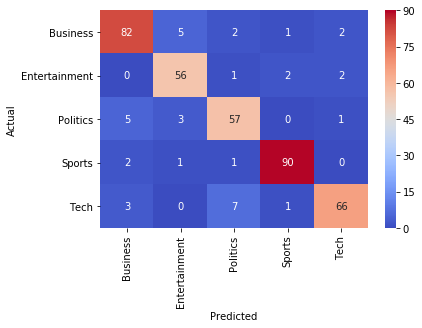

```python
_=sns.heatmap(confusion_RF_RE, cmap='coolwarm', annot=True)
plt.ylabel('Actual')
plt.xlabel('Predicted')
```

# Calculate number of correctly classified observations¶¶

```python
accuracy_score(Y_test, resample_predictions, normalize=False)
```

```
351
```

# Calculate number of incorrectly classified observations.¶¶

```python
len(Y_test) - accuracy_score(Y_test, resample_predictions, normalize=False)
```

```
39
```

**Using classification_report we can check the total precision,recall,f1-score,support of the individual classes of the target data

```python
print(classification_report(Y_test, resample_predictions))
```

```
               precision    recall  f1-score   support

     business       0.89      0.89      0.89        92
entertainment       0.86      0.92      0.89        61
     politics       0.84      0.86      0.85        66
        sport       0.96      0.96      0.96        94
         tech       0.93      0.86      0.89        77

    micro avg       0.90      0.90      0.90       390
    macro avg       0.90      0.90      0.90       390
 weighted avg       0.90      0.90      0.90       390
```

Calculate Area under the ROC curve and also plot the ROC curve

```python
probs_resample = model_resample.predict_proba(x_test)[::,1]
```

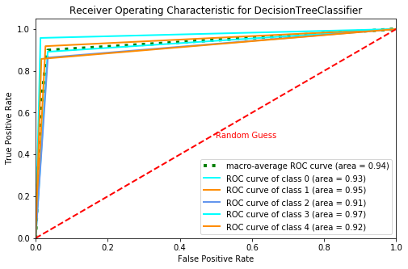

```python
plot_roc(model_resample, x_test, Y_test)
```

# Analysis of Decision Tree

1) Decision Tree model overfits the data - train data accuracy was observed to be 100% whereas on test data it reduced to 87%

3) By using bootstrap resampling, accuracy improved to 90%

# Random Forest for Classification

# Preparing the Data

As with the classification task, in this section we will divide our data into attributes and labels and consequently into training and test sets.

Execute the following commands to divide data into labels and attributes: Splitting the data into train (75%) and test(25%) of dependent and independent variables with random_state(seed) as 666 Provided:

# y: Single column dataframe holding our solution vector for classification

# x: A dataframe that runs parallel to y, with all the features for our classification

To train the tree, we'll instantiate the RandomForestClassifier type and call the fit method:

```python
rf_model = RandomForestClassifier(n_estimators=500, n_jobs=-1)
```

Train the model on training data.

```python
rf_model.fit(X_train, y_train)
```

```
RandomForestClassifier(bootstrap=True, class_weight=None, criterion='gini',
            max_depth=None, max_features='auto', max_leaf_nodes=None,
            min_impurity_decrease=0.0, min_impurity_split=None,
            min_samples_leaf=1, min_samples_split=2,
            min_weight_fraction_leaf=0.0, n_estimators=500, n_jobs=-1,
            oob_score=False, random_state=None, verbose=0,
            warm_start=False)
```

**Note that we didn't have to encode the response variable whhile using scikit-learn. We can also check the classes as:

```python
rf_model.classes_
```

```
array(['business', 'entertainment', 'politics', 'sport', 'tech'],
      dtype='<U13')
```

**Predictions of train data with X_test

```python
RF_predictions = rf_model.predict(X_test)
```

```python
RF_predictions[:5]
```

```
array(['business', 'sport', 'entertainment', 'tech', 'sport'],
      dtype='<U13')
```

# Calculating the score of train dataset

```python
rf_model.score(X_train,y_train)
```

```
1.0
```

# Calculating the score of test dataset

```python
# Calculating the score of test dataset of rf_model
rf_model.score(X_test, y_test)
```

```
0.9784560143626571
```

Random Forest is performing very well with this dataset

Error in prediction

```python
1-rf_model.score(X_test, y_test)
```

```
0.021543985637342944
```

# Calculate Accuracy

```python
accuracy_score(y_test, RF_predictions)
```

```
0.9784560143626571
```

** Now let's compare some of our predicted values with the actual values and see how accurate we were

```python
df_Random=pd.DataFrame({'Actual':y_test, 'Predicted':RF_predictions})
df_Random.head()
```

|  | Actual | Predicted |
| --- | --- | --- |
| 0 | business | business |
| 1 | sport | sport |
| 2 | entertainment | entertainment |
| 3 | tech | tech |
| 4 | sport | sport |

Remember that in your case the records compared may be different, depending upon the training and testing split. Since the train_test_split method randomly splits the data we likely won't have the same training and test sets.

# Calculate number of correctly classified observations

```python
accuracy_score(y_test, RF_predictions, normalize=False)
```

```
545
```

# Calculate number of incorrectly classified observations.¶¶

```python
len(y_test) - accuracy_score(y_test, RF_predictions, normalize=False)
```

```
12
```

```python
print('Accuracy of Random Forest classifier on test set: {:.2f}'.format(tree.score(X_test, y_test)))
```

[output not shown]

```python
print(classification_report(y_test, RF_predictions ))
```

```
               precision    recall  f1-score   support

     business       0.95      0.99      0.97       135
entertainment       1.00      0.98      0.99        85
     politics       0.99      0.93      0.96       104
        sport       0.98      1.00      0.99       131
         tech       0.99      0.98      0.99       102

    micro avg       0.98      0.98      0.98       557
    macro avg       0.98      0.98      0.98       557
 weighted avg       0.98      0.98      0.98       557
```

# Confusion matrix

```python
confusion_mat_RF = confusion_matrix(y_test, RF_predictions)
confusion_df_RF = pd.DataFrame(confusion_mat_RF, index=['Business','Entertainment',"Politics",'Sports','Tech'],                            columns=['Business','Entertainment',"Politics",'Sports','Tech'])
```

```python
confusion_df_RF
```

|  | Business | Entertainment | Politics | Sports | Tech |
| --- | --- | --- | --- | --- | --- |
| Business | 134 | 0 | 0 | 1 | 0 |
| Entertainment | 1 | 83 | 1 | 0 | 0 |
| Politics | 5 | 0 | 97 | 1 | 1 |
| Sports | 0 | 0 | 0 | 131 | 0 |
| Tech | 1 | 0 | 0 | 1 | 100 |

# visualisation of confustion matrix¶

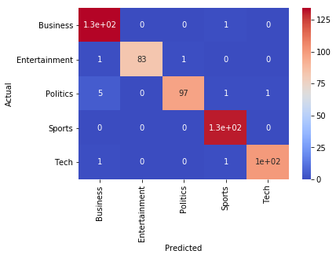

```python
_=sns.heatmap(confusion_df_RF, cmap='coolwarm', annot=True)
plt.ylabel('Actual')
plt.xlabel('Predicted')
```

# Calculate Area under the ROC curve and also plot the ROC curve

```python
probs_RF = rf_model.predict_proba(X_test)[::,1]
```

**Area and Roc Curve with Multiple classes of target variable(5)

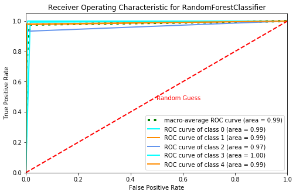

```python
plot_roc(rf_model, X_test, y_test)
```

# Analysis of Random Forest Model Evaluation

1) Random Forest is providing excellent accuracy of 97.8%

3) Random Forest uses resampling inernally hence resampling is not needed

4) Random Forest reduces variance compared to DT by using random subset of featuers and also by using multiple decision trees (a forest of trees) Hence its accuracy is better

# Voting Classifier Ensemble using Scikit-Learn

Create an ensemble of Logistic and Decision Tree classifiers and Random Forest Classifier use majority vote to make the predictions from ensemble.

```python
log_model = LogisticRegression()
dtree_model = DecisionTreeClassifier()
Randomf_model = RandomForestClassifier(n_estimators=500, n_jobs=-1)
```

# Train the model on training data.

```python
ensemble = VotingClassifier(estimators=[('lr', log_model), ('dtree', dtree_model),('rforest',Randomf_model)], voting='hard')
```

Train the model on training data.

```python
ensemble.fit(X_train, y_train)
```

```
VotingClassifier(estimators=[('lr', LogisticRegression(C=1.0, class_weight=None, dual=False, fit_intercept=True,
          intercept_scaling=1, max_iter=100, multi_class='warn',
          n_jobs=None, penalty='l2', random_state=None, solver='warn',
          tol=0.0001, verbose=0, warm_start=False)), ('dtree', Decis..._jobs=-1,
            oob_score=False, random_state=None, verbose=0,
            warm_start=False))],
         flatten_transform=None, n_jobs=None, voting='hard', weights=None)
```

It is noted that ensemble fitting is computationally intensive and takes time

Accuracy with ensemble

```python
predictions = ensemble.predict(X_test)
accuracy_score(y_test, predictions)
```

```
0.9712746858168761
```

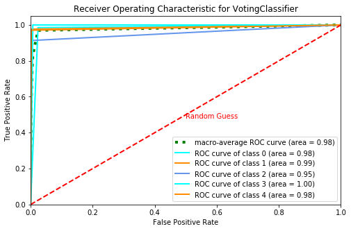

```python
plot_roc(ensemble, X_test, y_test)
```

# Analysis of VotingClassifier

1) Voting Classifier is giving extremely good accuracy (~97%)

3) Voting Classifier is resource intensive (takes time to compute)

# Compare Accuracies across Models

```python
from sklearn.metrics import accuracy_score
```

```python
models = [
    log_model,
    dtree_model,
    Randomf_model,
    ensemble
]

for model in models:
    model.fit(X_train, y_train)
    predictions = model.predict(X_test)
    print(model.__class__.__name__, accuracy_score(y_test, predictions))
    print(model.__class__.__name__, classification_report(y_test, predictions))
```

```
LogisticRegression 0.9820466786355476
LogisticRegression                precision    recall  f1-score   support

     business       0.96      0.99      0.97       135
entertainment       1.00      0.98      0.99        85
     politics       0.99      0.96      0.98       104
        sport       0.98      1.00      0.99       131
         tech       0.99      0.98      0.99       102

    micro avg       0.98      0.98      0.98       557
    macro avg       0.98      0.98      0.98       557
 weighted avg       0.98      0.98      0.98       557

DecisionTreeClassifier 0.8599640933572711
DecisionTreeClassifier                precision    recall  f1-score   support

     business       0.82      0.85      0.83       135
entertainment       0.91      0.85      0.88        85
     politics       0.81      0.84      0.82       104
        sport       0.92      0.89      0.90       131
         tech       0.86      0.87      0.86       102

    micro avg       0.86      0.86      0.86       557
    macro avg       0.86      0.86      0.86       557
 weighted avg       0.86      0.86      0.86       557

RandomForestClassifier 0.9748653500897666
RandomForestClassifier                precision    recall  f1-score   support

     business       0.94      0.99      0.96       135
entertainment       1.00      0.98      0.99        85
     politics       0.98      0.92      0.95       104
        sport       0.98      1.00      0.99       131
         tech       0.99      0.98      0.99       102

    micro avg       0.97      0.97      0.97       557
    macro avg       0.98      0.97      0.98       557
 weighted avg       0.98      0.97      0.97       557
```

```
VotingClassifier 0.9676840215439856
VotingClassifier                precision    recall  f1-score   support

     business       0.92      0.99      0.95       135
entertainment       1.00      0.96      0.98        85
     politics       0.97      0.90      0.94       104
        sport       0.99      1.00      1.00       131
         tech       0.98      0.97      0.98       102

    micro avg       0.97      0.97      0.97       557
    macro avg       0.97      0.96      0.97       557
 weighted avg       0.97      0.97      0.97       557
```

### As can be seen, Logistic Regression is giving the best accuracy of ~98%, while RandomForest and VotingClassifier are close with ~97% accuracy

Given that there only 5 classes and they are almost linearly seperable, it fits well with LogisticRegression and might explain its higher score

### Decision Tree scores lower due to its known 'bias'/overfitting to train dataset

# Cross Validate with 5 different folds of 20% data ( 80-20 split with 5 folds )

```python
CV = 5
#Create a data frame that will store the results for all 5 trials of the 3 different models
cv_df = pd.DataFrame(index=range(CV * len(models)))
entries = [] # Initially all entries are empty
```

```python
from sklearn.model_selection import cross_val_score
#For each Algorithm
for model in models:
  model_name = model.__class__.__name__
  # create 5 models with different 20% test sets, and store their accuracies
  accuracies = cross_val_score(model, X, Y, scoring='accuracy', cv=CV)
  # Append all 5 accuracies into the entries list ( after all 3 models are run, there will be 3x5 = 15 entries)
  for fold_idx, accuracy in enumerate(accuracies):
    entries.append((model_name, fold_idx, accuracy))

# Store the entries into the results dataframe and name its columns
cv_df = pd.DataFrame(entries, columns=['model_name', 'fold_idx', 'accuracy'])
```

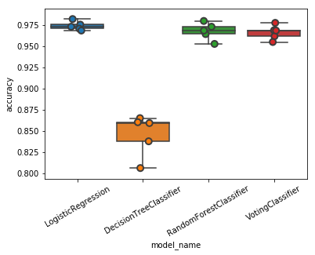

```python
import seaborn as sns

ax= sns.boxplot(x='model_name', y='accuracy', data=cv_df)
ax.set_xticklabels(ax.get_xticklabels(),rotation=30)
sns.stripplot(x='model_name', y='accuracy', data=cv_df,
              size=8, jitter=True, edgecolor="gray", linewidth=2)
```

The above BoXplot nicely gives a visual comparison of the model accuracies for the test dataset.

### As analyzed, LogisticRegression gives the best evaluation metrics and hence is recommended for this problem